# Simpson’s Paradox & Treatment Effect Estimation (Simulated)

Huan Deng

# Part 1. Simpson’s Paradox (Simulated)

We simulate two groups (A = high baseline, B = low baseline). Treatment effects are **positive within each group**, but treated units are more likely to come from Group B (the worse baseline group). The pooled comparison appears negative (Simpson’s paradox).

```r
n <- 5000
G <- rbinom(n, 1, 0.5)  # 1=A, 0=B
muA <- 80; muB <- 50    # baseline means
tau <- 10               # true TE within each group

# Treatment assignment favored toward low-baseline group B
pD_A <- 0.20
pD_B <- 0.80
D <- ifelse(G==1, rbinom(n,1,pD_A), rbinom(n,1,pD_B))

# Outcomes
mu0 <- ifelse(G==1, muA, muB)
Y <- mu0 + tau*D + rnorm(n, 0, 10)

dat_sp <- data.frame(G=factor(G, labels=c("B","A")), D=factor(D), Y)
dplyr::glimpse(dat_sp)
```

```
## Rows: 5,000
## Columns: 3
## $ G <fct> B, A, B, A, A, B, A, A, A, B, A, B, A, A, B, A, B, B, B, A, A, A, A,…
## $ D <fct> 1, 1, 0, 0, 0, 1, 0, 0, 0, 1, 0, 1, 0, 1, 1, 1, 1, 1, 1, 0, 1, 1, 0,…
## $ Y <dbl> 63.50003, 98.14442, 44.83334, 53.07736, 69.03045, 47.44525, 73.62789…
```

## Naïve difference in means (pooled)

```r
naive_diff <- with(dat_sp, mean(Y[D=="1"]) - mean(Y[D=="0"]))
naive_diff
```

```
## [1] -8.403165
```

## Within-group treatment effects

```r
within_te <- dat_sp |>
  dplyr::group_by(G) |>
  dplyr::summarise(TE = mean(Y[D=="1"]) - mean(Y[D=="0"]),
                   n = dplyr::n())
within_te
```

```
## # A tibble: 2 × 3
##   G        TE     n
##   <fct> <dbl> <int>
## 1 B      8.40  2521
## 2 A     11.3   2479
```

## Correct stratified ATE (weighted by group shares)

```r
wA <- mean(dat_sp$G=="A")
wB <- mean(dat_sp$G=="B")
tau_A <- within_te$TE[within_te$G=="A"]
tau_B <- within_te$TE[within_te$G=="B"]
strat_ate <- wA*tau_A + wB*tau_B
c(naive_diff = naive_diff, stratified_ATE = strat_ate)
```

```
##     naive_diff stratified_ATE
##      -8.403165       9.843925
```

## Visualization

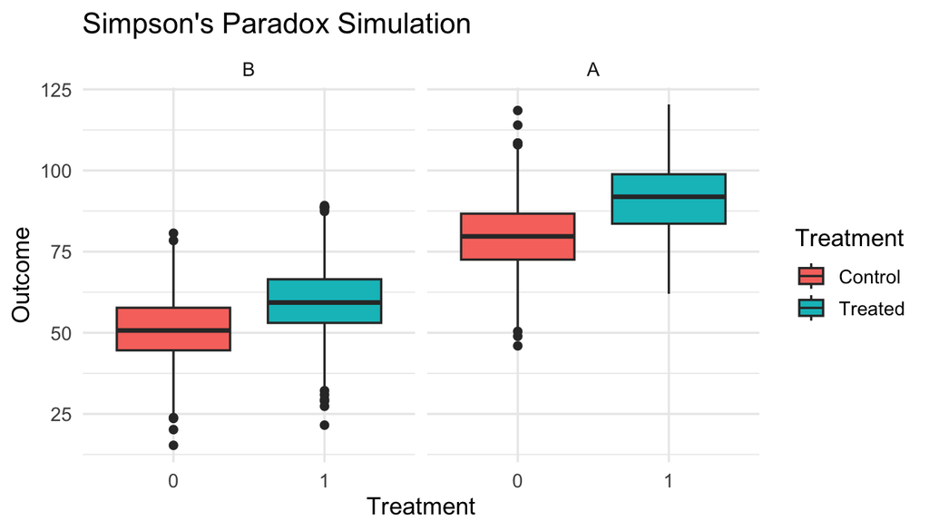

```r
ggplot(dat_sp, aes(x=D, y=Y, fill=D)) +
  geom_boxplot() +
  facet_wrap(~G) +
  scale_fill_discrete(name="Treatment", labels=c("Control","Treated")) +
  labs(x="Treatment", y="Outcome", title="Simpson's Paradox Simulation") +
  theme_minimal(base_size = 13)
```

# Part 2. Training Program (Selection on Observables)

We simulate a government assigning training based on education, baseline income, presence of young kids, and age. Treatment assignment uses a logistic rule; outcomes depend on covariates plus a *constant* treatment effect. Under **CIA (unconfoundedness)**, appropriate estimators should recover the ATE when overlap is decent.

```r
logit <- function(x) 1/(1+exp(-x))

simulate_training <- function(N=8000){
  edu <- rbinom(N,1,0.5)     # 1=College+, 0=HS or less
  base_inc <- rnorm(N, mean = ifelse(edu==1, 30, 20), sd=8)
  kids <- rbinom(N,1,0.35)   # has young kids
  age <- pmin(pmax(round(rnorm(N,36,7)),22),55)

  # Government targeting rule (higher prob if HSorLess, lower income, has kids)
  linp <- -0.2 - 0.20*edu - 0.02*base_inc + 0.20*kids - 0.005*age
  e_true <- 1/(1+exp(-linp))           # plogis(linp)
  D <- rbinom(N, 1, e_true)

  # Outcomes: post-training earnings (k$)
  mu0 <- 10 + 0.8*base_inc + 2*edu -1.5*kids + 0.1*age
  tau <- 3  # constant TE for clarity
  Y0 <- mu0 + rnorm(N,0,5)
  Y1 <- mu0 + tau + rnorm(N,0,5)
  Y <- ifelse(D==1, Y1, Y0)

  data.frame(edu, base_inc, kids, age, D, Y, e_true, Y0, Y1)
}

dat <- simulate_training(8000)
true_ATE <- mean(dat$Y1 - dat$Y0)
true_ATE
```

```
## [1] 2.977575
```

## Quick overlap check (estimated propensity)

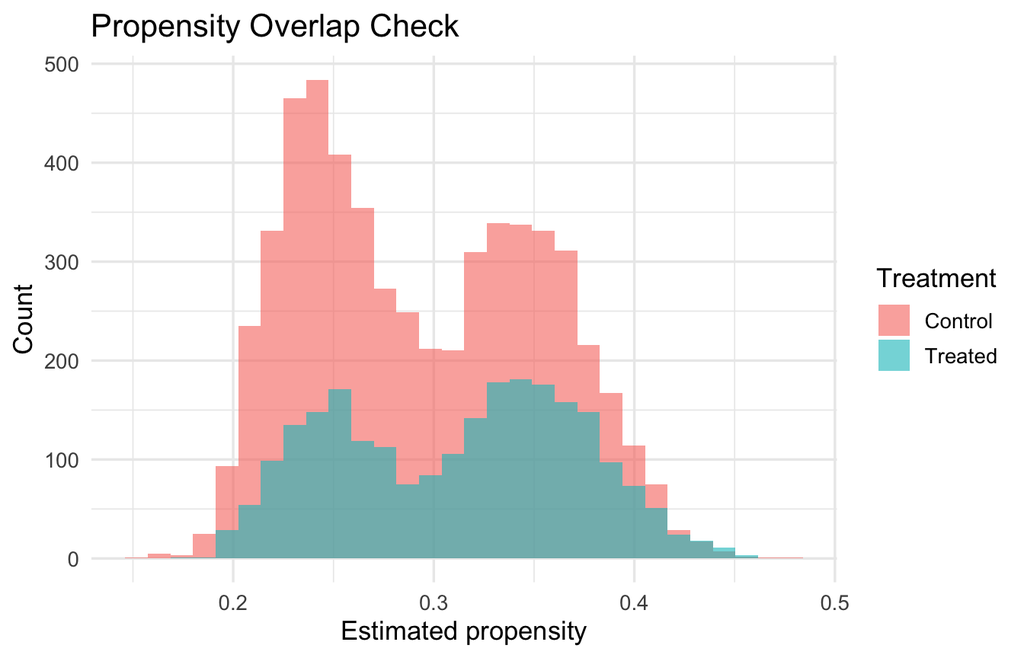

```r
ps_fit <- glm(D ~ edu + base_inc + kids + age, data=dat, family=binomial)
dat$e_hat <- as.numeric(fitted(ps_fit))

ggplot(dat, aes(x=e_hat, fill=factor(D))) +
  geom_histogram(alpha=0.6, bins=30, position="identity") +
  scale_fill_discrete(name="Treatment", labels=c("Control","Treated")) +
  labs(x="Estimated propensity", y="Count", title="Propensity Overlap Check") +
  theme_minimal(base_size = 13)
```

## Estimators

### 1) Naïve difference in means

```r
est_naive <- with(dat, mean(Y[D==1]) - mean(Y[D==0]))
est_naive
```

```
## [1] 0.9065591
```

### 2) OLS with controls

```r
est_ols <- coef(lm(Y ~ D + edu + base_inc + kids + age, data=dat))["D"]
est_ols
```

```
##        D
## 2.997974
```

### 3) Propensity score stratification (subclassification) — using `MatchIt`

We create 5 subclasses by the estimated propensity score, then compute a subclass-weighted difference in means (ATE target).

```r
m.out <- matchit(D ~ edu + base_inc + kids + age, data=dat,
                 method="subclass", subclass=5, estimand="ATE")
# Extract subclass labels and compute subclass-specific diffs
md <- MatchIt::match.data(m.out)
sub_diffs <- md |>
  dplyr::group_by(subclass) |>
  dplyr::summarise(tau_j = mean(Y[D==1]) - mean(Y[D==0]),
                   n_j = dplyr::n())
# Weight subclasses by their sample share
est_ps_subclass <- with(sub_diffs, sum((n_j/sum(n_j)) * tau_j))
list(subclass_diffs = sub_diffs, ATE_ps_subclass = est_ps_subclass)
```

```
## $subclass_diffs
## # A tibble: 5 × 3
##   subclass tau_j   n_j
##   <fct>    <dbl> <int>
## 1 1         2.06  1600
## 2 2         2.75  1600
## 3 3         3.45  1600
## 4 4         3.29  1600
## 5 5         2.54  1600
##
## $ATE_ps_subclass
## [1] 2.818422
```

### 4) Inverse Probability Weighting (IPW) — using `WeightIt` + `survey`

```r
w.out <- weightit(D ~ edu + base_inc + kids + age, data=dat,
                  method="ps", estimand="ATE")
dat$w_ipw <- w.out$weights

des_ipw <- svydesign(~1, weights=~w_ipw, data=dat)
est_ipw <- coef(svyglm(Y ~ D, design=des_ipw))["D"]
est_ipw
```

```
##        D
## 2.971589
```

### 5) Augmented IPW (AIPW) — custom implementation

```r
# Propensity
ps <- glm(D ~ edu + base_inc + kids + age, data=dat, family=binomial)$fitted

# Outcome models
mu1_hat <- predict(lm(Y ~ edu + base_inc + kids + age, data=dat[dat$D==1,]), newdata=dat)
mu0_hat <- predict(lm(Y ~ edu + base_inc + kids + age, data=dat[dat$D==0,]), newdata=dat)

# AIPW estimating equation
term1 <- mu1_hat - mu0_hat
term2 <- dat$D       * (dat$Y - mu1_hat) / ps
term3 <- (1 - dat$D) * (dat$Y - mu0_hat) / (1 - ps)

est_aipw <- mean(term1 + term2 - term3)
est_aipw
```

```
## [1] 2.982088
```

## Summary: compare estimates to the true ATE

```r
c(True_ATE = true_ATE,
  Naive = est_naive,
  OLS = est_ols,
  PS_Subclass = est_ps_subclass,
  IPW = unname(est_ipw),
  AIPW = est_aipw)
```

```
##    True_ATE       Naive       OLS.D PS_Subclass         IPW        AIPW
##   2.9775753   0.9065591   2.9979736   2.8184216   2.9715892   2.9820882
```

# Part 3. Doubly Robust (DR) Illustration: When One Model Is Wrong

We stress‑test the **AIPW (doubly robust)** estimator by deliberately misspecifying either the **propensity score model** or the **outcome regression**, and then both.  
Under standard regularity, AIPW is consistent if **either** the propensity model **or** the outcome model is correctly specified (but not necessarily both).

We reuse `dat` from Part 2.

```r
# AIPW helper that accepts arbitrary ps and outcome predictions
aipw_est <- function(Y, D, ps, mu1_hat, mu0_hat){
  term1 <- mu1_hat - mu0_hat
  term2 <- D       * (Y - mu1_hat) / ps
  term3 <- (1 - D) * (Y - mu0_hat) / (1 - ps)
  mean(term1 + term2 - term3)
}
```

## Model Specifications

- **Propensity score (PS):**
  - **Correct PS**: logistic with `edu + base_inc + kids + age` (matches DGP).
  - **Misspecified PS**: logistic with only `edu + kids` (omits key confounders `base_inc`, `age`).
- **Outcome regressions (OR):**
  - **Correct OR**: linear model `Y ~ edu + base_inc + kids + age` (matches DGP mean function, up to noise).
  - **Misspecified OR**: linear model `Y ~ edu + kids` (omits `base_inc`, `age`).

```r
# PS
ps_good <- glm(D ~ edu + base_inc + kids + age, data=dat, family=binomial)$fitted
ps_bad  <- glm(D ~ edu + kids,                 data=dat, family=binomial)$fitted

# Outcome models
m1_good <- lm(Y ~ edu + base_inc + kids + age, data=dat[dat$D==1,])
m0_good <- lm(Y ~ edu + base_inc + kids + age, data=dat[dat$D==0,])
mu1_good <- predict(m1_good, newdata = dat)
mu0_good <- predict(m0_good, newdata = dat)

m1_bad <- lm(Y ~ edu + kids, data=dat[dat$D==1,])
m0_bad <- lm(Y ~ edu + kids, data=dat[dat$D==0,])
mu1_bad <- predict(m1_bad, newdata = dat)
mu0_bad <- predict(m0_bad, newdata = dat)
```

## Estimates Under Correct vs. Misspecified Pieces

We report: - **IPW** using good vs. bad PS; - **Outcome regression (RA)** using good vs. bad outcome models; - **AIPW (DR)** in three combinations: (good PS, bad OR), (bad PS, good OR), and (bad PS, bad OR).

```r
library(dplyr)

# IPW with good/bad PS (stabilized HT form)
ipw_ht <- function(Y, D, ps){
  num1 <- sum(D * Y / ps);     den1 <- sum(D / ps)
  num0 <- sum((1-D) * Y / (1-ps)); den0 <- sum((1-D) / (1-ps))
  (num1/den1) - (num0/den0)
}
ipw_good <- ipw_ht(dat$Y, dat$D, ps_good)
ipw_bad  <- ipw_ht(dat$Y, dat$D, ps_bad)

# Regression adjustment (RA): average of predicted contrasts
ra_good <- mean(mu1_good - mu0_good)
ra_bad  <- mean(mu1_bad  - mu0_bad)

# AIPW combos
aipw_goodPS_badOR <- aipw_est(dat$Y, dat$D, ps_good, mu1_bad,  mu0_bad)
aipw_badPS_goodOR <- aipw_est(dat$Y, dat$D, ps_bad,  mu1_good, mu0_good)
aipw_badPS_badOR  <- aipw_est(dat$Y, dat$D, ps_bad,  mu1_bad,  mu0_bad)

res_dr <- tibble::tibble(
  Estimator = c("True ATE",
                "IPW (good PS)", "IPW (bad PS)",
                "RA  (good OR)", "RA  (bad OR)",
                "AIPW (good PS, bad OR)",
                "AIPW (bad PS, good OR)",
                "AIPW (bad PS, bad OR)"),
  Value = c(true_ATE, ipw_good, ipw_bad, ra_good, ra_bad,
            aipw_goodPS_badOR, aipw_badPS_goodOR, aipw_badPS_badOR)
)

res_dr
```

```
## # A tibble: 8 × 2
##   Estimator              Value
##   <chr>                  <dbl>
## 1 True ATE                2.98
## 2 IPW (good PS)           2.97
## 3 IPW (bad PS)            2.19
## 4 RA  (good OR)           2.99
## 5 RA  (bad OR)            2.19
## 6 AIPW (good PS, bad OR)  2.97
## 7 AIPW (bad PS, good OR)  2.99
## 8 AIPW (bad PS, bad OR)   2.19
```

### Takeaways

- **IPW** is consistent only when the **PS is correctly specified** (compare “IPW good PS” vs “IPW bad PS”).
- **Outcome regression (RA)** is consistent only when the **outcome model is correctly specified**.
- **AIPW** remains close to the **True ATE** when **either** the PS **or** the OR is correct (rows “AIPW (good PS, bad OR)” and “AIPW (bad PS, good OR)”).
- When **both** PS and OR are misspecified, **AIPW** also fails (row “AIPW (bad PS, bad OR)”).

You can change which covariates are omitted, or add nonlinearities (e.g., include `base_inc^2` in the DGP but not in the models) to create more dramatic gaps.